# Ensemble Modeling: Stack Model Example

J. Thompson

September 6, 2016

This paper illustrates an ensemble model approach to generate the submission data set for the Kaggle **House Price** competition. Ensemble modeling involves training multiple models and combining their predictions to derive the predictions submitted to Kaggle. The specific ensemble approach illustrated is called model stacking.

The diagram below shows the high-level model stacking architecture, which is composed of two stages. The top-level stage, called Level 0, is composed of three modeling algorithms: Gradient Boosting (gbm), Extreme Gradient Boosting (xgb) and Random Forest (rngr). The second stage, Level 1, is composed of a single Neural Network (nnet) model. The predictions from Level 1 are used to create the Kaggle submission data set.

**Feature Sets** in the diagram reprsents one or more sets of attributes created for the Level 0 models.

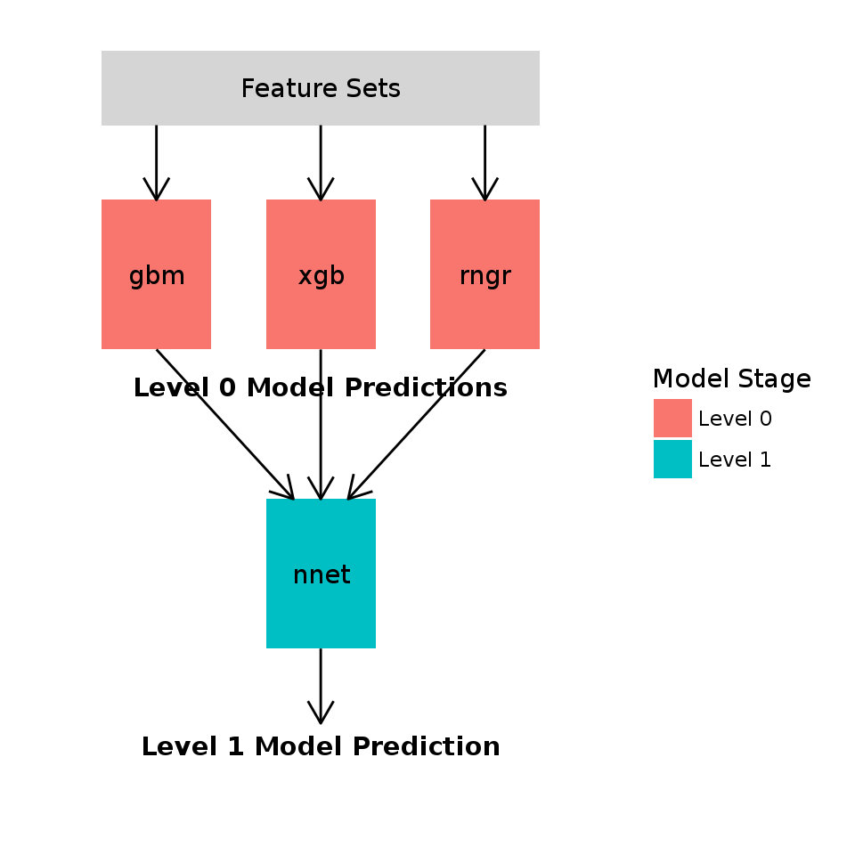

The following chart shows the model performance of the individual Level 0 models versus the overall stacked model.

[figure not shown]

From the above chart we see that the Level 1 model is a 1.35% improvement over the best performing Level 0 model.

To fit within the constraints of Kaggle’s Kernel offering, a simplified structure for the stacked model was used in this report. The specific simplications are

- Limit Level 0 to three models
- LImit Level 1 to one model

Improvements in stacked model performance can be accomplished by

- Adding models to Level 0 and Level 1 using different algorithms
- Tuning model Hyper-parameters
- Adding feature sets by feature engineering
- Adding levels in the model structure

For additional information on model stacking see these references:

- [MLWave: Kaggle Ensembling Guide](http://mlwave.com/kaggle-ensembling-guide/)
- [Kaggle Forum Posting: Stacking](https://www.kaggle.com/forums/f/208/getting-started/t/18153/stacking/103381)
- [Winning Data Science Competitions: Jeong-Yoon Lee](https://www.youtube.com/watch?v=ClAZQI_B4t8) This talk is about 90 minutes long. The sections relevant to model stacking are discussed in these segments (h:mm:ss to h:mm:ss): 1:05:25 to 1:12:15 and 1:21:30 to 1:27:00.

The remainder of this paper demonstrates the model stacking training pipeline. First we show an approach for creating model feature sets. Next we demonstrate an approach for training Level 0 models using the [caret package](https://cran.r-project.org/web/packages/caret/index.html). Then we end with creating features for the Level 1 model and creating the Kaggle submission data set.

# Data Preparation

## Retrieve Data

```r
train.raw <- read.csv(file.path(DATA.DIR,"train.csv"),stringsAsFactors = FALSE)

test.raw <- read.csv(file.path(DATA.DIR,"test.csv"), stringsAsFactors = FALSE)
```

## Initial Data Profile

Feature selection is based on an [earlier Boruta](https://www.kaggle.com/jimthompson/house-prices-advanced-regression-techniques/boruta-feature-importance-analysis) feature importance analysis.

```r
# incorporate results of Boruta analysis
CONFIRMED_ATTR <- c("MSSubClass","MSZoning","LotArea","LotShape","LandContour","Neighborhood",
                    "BldgType","HouseStyle","OverallQual","OverallCond","YearBuilt",
                    "YearRemodAdd","Exterior1st","Exterior2nd","MasVnrArea","ExterQual",
                    "Foundation","BsmtQual","BsmtCond","BsmtFinType1","BsmtFinSF1",
                    "BsmtFinType2","BsmtUnfSF","TotalBsmtSF","HeatingQC","CentralAir",
                    "X1stFlrSF","X2ndFlrSF","GrLivArea","BsmtFullBath","FullBath","HalfBath",
                    "BedroomAbvGr","KitchenAbvGr","KitchenQual","TotRmsAbvGrd","Functional",
                    "Fireplaces","FireplaceQu","GarageType","GarageYrBlt","GarageFinish",
                    "GarageCars","GarageArea","GarageQual","GarageCond","PavedDrive","WoodDeckSF",
                    "OpenPorchSF","Fence")

TENTATIVE_ATTR <- c("Alley","LandSlope","Condition1","RoofStyle","MasVnrType","BsmtExposure",
                    "Electrical","EnclosedPorch","SaleCondition")

REJECTED_ATTR <- c("LotFrontage","Street","Utilities","LotConfig","Condition2","RoofMatl",
                   "ExterCond","BsmtFinSF2","Heating","LowQualFinSF","BsmtHalfBath",
                   "X3SsnPorch","ScreenPorch","PoolArea","PoolQC","MiscFeature","MiscVal",
                   "MoSold","YrSold","SaleType")

PREDICTOR_ATTR <- c(CONFIRMED_ATTR,TENTATIVE_ATTR,REJECTED_ATTR)

# Determine data types in the data set
data_types <- sapply(PREDICTOR_ATTR,function(x){class(train.raw[[x]])})
unique_data_types <- unique(data_types)

# Separate attributes by data type
DATA_ATTR_TYPES <- lapply(unique_data_types,function(x){ names(data_types[data_types == x])})
names(DATA_ATTR_TYPES) <- unique_data_types


# create folds for training
set.seed(13)
data_folds <- createFolds(train.raw$SalePrice, k=5)
```

## Create Level 0 Model Feature Sets

For this work, two feature sets were created. Both of these sets included Boruta Confirmed and Tentative attributes.

Each feature set is created by a specific user-defined R function. These functions convert the raw training data into a feature set.

No extensive feature engineering was performed. Missing values are handled as follows:

- Numeric: set to -1
- Character: set to “*MISSING*”

Character attributes are converted to R factor variables.

```r
# Feature Set 1 - Boruta Confirmed and tentative Attributes
prepL0FeatureSet1 <- function(df) {
    id <- df$Id
    if (class(df$SalePrice) != "NULL") {
        y <- log(df$SalePrice)
    } else {
        y <- NULL
    }


    predictor_vars <- c(CONFIRMED_ATTR,TENTATIVE_ATTR)

    predictors <- df[predictor_vars]

    # for numeric set missing values to -1 for purposes
    num_attr <- intersect(predictor_vars,DATA_ATTR_TYPES$integer)
    for (x in num_attr){
      predictors[[x]][is.na(predictors[[x]])] <- -1
    }

    # for character  atributes set missing value
    char_attr <- intersect(predictor_vars,DATA_ATTR_TYPES$character)
    for (x in char_attr){
      predictors[[x]][is.na(predictors[[x]])] <- "*MISSING*"
      predictors[[x]] <- factor(predictors[[x]])
    }

    return(list(id=id,y=y,predictors=predictors))
}

L0FeatureSet1 <- list(train=prepL0FeatureSet1(train.raw),
                    test=prepL0FeatureSet1(test.raw))

# Feature Set 2 (xgboost) - Boruta Confirmed Attributes
prepL0FeatureSet2 <- function(df) {
    id <- df$Id
    if (class(df$SalePrice) != "NULL") {
        y <- log(df$SalePrice)
    } else {
        y <- NULL
    }


    predictor_vars <- c(CONFIRMED_ATTR,TENTATIVE_ATTR)

    predictors <- df[predictor_vars]

    # for numeric set missing values to -1 for purposes
    num_attr <- intersect(predictor_vars,DATA_ATTR_TYPES$integer)
    for (x in num_attr){
      predictors[[x]][is.na(predictors[[x]])] <- -1
    }

    # for character  atributes set missing value
    char_attr <- intersect(predictor_vars,DATA_ATTR_TYPES$character)
    for (x in char_attr){
      predictors[[x]][is.na(predictors[[x]])] <- "*MISSING*"
      predictors[[x]] <- as.numeric(factor(predictors[[x]]))
    }

    return(list(id=id,y=y,predictors=as.matrix(predictors)))
}

L0FeatureSet2 <- list(train=prepL0FeatureSet2(train.raw),
                    test=prepL0FeatureSet2(test.raw))
```

## Level 0 Model Training

### Helper Function For Training

```r
#train model on one data fold
trainOneFold <- function(this_fold,feature_set) {
    # get fold specific cv data
    cv.data <- list()
    cv.data$predictors <- feature_set$train$predictors[this_fold,]
    cv.data$ID <- feature_set$train$id[this_fold]
    cv.data$y <- feature_set$train$y[this_fold]

    # get training data for specific fold
    train.data <- list()
    train.data$predictors <- feature_set$train$predictors[-this_fold,]
    train.data$y <- feature_set$train$y[-this_fold]


    set.seed(825)
    fitted_mdl <- do.call(train,
                          c(list(x=train.data$predictors,y=train.data$y),
                        CARET.TRAIN.PARMS,
                        MODEL.SPECIFIC.PARMS,
                        CARET.TRAIN.OTHER.PARMS))

    yhat <- predict(fitted_mdl,newdata = cv.data$predictors,type = "raw")

    score <- rmse(cv.data$y,yhat)

    ans <- list(fitted_mdl=fitted_mdl,
                score=score,
                predictions=data.frame(ID=cv.data$ID,yhat=yhat,y=cv.data$y))

    return(ans)

}

# make prediction from a model fitted to one fold
makeOneFoldTestPrediction <- function(this_fold,feature_set) {
    fitted_mdl <- this_fold$fitted_mdl

    yhat <- predict(fitted_mdl,newdata = feature_set$test$predictors,type = "raw")

    return(yhat)
}
```

### gbm Model

Public Leaderboard Score: 0.12852

```r
# set caret training parameters
CARET.TRAIN.PARMS <- list(method="gbm")

CARET.TUNE.GRID <-  expand.grid(n.trees=100,
                                interaction.depth=10,
                                shrinkage=0.1,
                                n.minobsinnode=10)

MODEL.SPECIFIC.PARMS <- list(verbose=0) #NULL # Other model specific parameters

# model specific training parameter
CARET.TRAIN.CTRL <- trainControl(method="none",
                                 verboseIter=FALSE,
                                 classProbs=FALSE)

CARET.TRAIN.OTHER.PARMS <- list(trControl=CARET.TRAIN.CTRL,
                           tuneGrid=CARET.TUNE.GRID,
                           metric="RMSE")

# generate features for Level 1
gbm_set <- llply(data_folds,trainOneFold,L0FeatureSet1)

# final model fit
gbm_mdl <- do.call(train,
                 c(list(x=L0FeatureSet1$train$predictors,y=L0FeatureSet1$train$y),
                 CARET.TRAIN.PARMS,
                 MODEL.SPECIFIC.PARMS,
                 CARET.TRAIN.OTHER.PARMS))

# CV Error Estimate
cv_y <- do.call(c,lapply(gbm_set,function(x){x$predictions$y}))
cv_yhat <- do.call(c,lapply(gbm_set,function(x){x$predictions$yhat}))
rmse(cv_y,cv_yhat)
```

```
## [1] 0.1309466
```

```r
cat("Average CV rmse:",mean(do.call(c,lapply(gbm_set,function(x){x$score}))))
```

```
## Average CV rmse: 0.1304117
```

```r
# create test submission.
# A prediction is made by averaging the predictions made by using the models
# fitted for each fold.

test_gbm_yhat <- predict(gbm_mdl,newdata = L0FeatureSet1$test$predictors,type = "raw")
gbm_submission <- cbind(Id=L0FeatureSet1$test$id,SalePrice=exp(test_gbm_yhat))
write.csv(gbm_submission,file="gbm_sumbission.csv",row.names=FALSE)
```

### xgboost Model

Public Leader Board Score: 0.13696

```r
# set caret training parameters
CARET.TRAIN.PARMS <- list(method="xgbTree")

CARET.TUNE.GRID <-  expand.grid(nrounds=800,
                                max_depth=10,
                                eta=0.03,
                                gamma=0.1,
                                colsample_bytree=0.4,
                                min_child_weight=1)

MODEL.SPECIFIC.PARMS <- list(verbose=0) #NULL # Other model specific parameters

# model specific training parameter
CARET.TRAIN.CTRL <- trainControl(method="none",
                                 verboseIter=FALSE,
                                 classProbs=FALSE)

CARET.TRAIN.OTHER.PARMS <- list(trControl=CARET.TRAIN.CTRL,
                           tuneGrid=CARET.TUNE.GRID,
                           metric="RMSE")

# generate Level 1 features
xgb_set <- llply(data_folds,trainOneFold,L0FeatureSet2)

# final model fit
xgb_mdl <- do.call(train,
                 c(list(x=L0FeatureSet2$train$predictors,y=L0FeatureSet2$train$y),
                 CARET.TRAIN.PARMS,
                 MODEL.SPECIFIC.PARMS,
                 CARET.TRAIN.OTHER.PARMS))

# CV Error Estimate
cv_y <- do.call(c,lapply(xgb_set,function(x){x$predictions$y}))
cv_yhat <- do.call(c,lapply(xgb_set,function(x){x$predictions$yhat}))
rmse(cv_y,cv_yhat)
```

```
## [1] 0.1294368
```

```r
cat("Average CV rmse:",mean(do.call(c,lapply(xgb_set,function(x){x$score}))))
```

```
## Average CV rmse: 0.1287072
```

```r
# create test submission.
# A prediction is made by averaging the predictions made by using the models
# fitted for each fold.

test_xgb_yhat <- predict(xgb_mdl,newdata = L0FeatureSet2$test$predictors,type = "raw")
xgb_submission <- cbind(Id=L0FeatureSet2$test$id,SalePrice=exp(test_xgb_yhat))

write.csv(xgb_submission,file="xgb_sumbission.csv",row.names=FALSE)
```

### ranger Model

Public Leader Board Score: 0.14703

```r
# set caret training parameters
CARET.TRAIN.PARMS <- list(method="ranger")

CARET.TUNE.GRID <-  expand.grid(mtry=2*as.integer(sqrt(ncol(L0FeatureSet1$train$predictors))))

MODEL.SPECIFIC.PARMS <- list(verbose=0,num.trees=500) #NULL # Other model specific parameters

# model specific training parameter
CARET.TRAIN.CTRL <- trainControl(method="none",
                                 verboseIter=FALSE,
                                 classProbs=FALSE)

CARET.TRAIN.OTHER.PARMS <- list(trControl=CARET.TRAIN.CTRL,
                           tuneGrid=CARET.TUNE.GRID,
                           metric="RMSE")

# generate Level 1 features
rngr_set <- llply(data_folds,trainOneFold,L0FeatureSet1)

# final model fit
rngr_mdl <- do.call(train,
                 c(list(x=L0FeatureSet1$train$predictors,y=L0FeatureSet1$train$y),
                 CARET.TRAIN.PARMS,
                 MODEL.SPECIFIC.PARMS,
                 CARET.TRAIN.OTHER.PARMS))

# CV Error Estimate
cv_y <- do.call(c,lapply(rngr_set,function(x){x$predictions$y}))
cv_yhat <- do.call(c,lapply(rngr_set,function(x){x$predictions$yhat}))
rmse(cv_y,cv_yhat)
```

```
## [1] 0.1388838
```

```r
cat("Average CV rmse:",mean(do.call(c,lapply(rngr_set,function(x){x$score}))))
```

```
## Average CV rmse: 0.1376416
```

```r
# create test submission.
# A prediction is made by averaging the predictions made by using the models
# fitted for each fold.

test_rngr_yhat <- predict(rngr_mdl,newdata = L0FeatureSet1$test$predictors,type = "raw")
rngr_submission <- cbind(Id=L0FeatureSet1$test$id,SalePrice=exp(test_rngr_yhat))

write.csv(rngr_submission,file="rngr_sumbission.csv",row.names=FALSE)
```

## Level 1 Model Training

### Create predictions For Level 1 Model

```r
gbm_yhat <- do.call(c,lapply(gbm_set,function(x){x$predictions$yhat}))
xgb_yhat <- do.call(c,lapply(xgb_set,function(x){x$predictions$yhat}))
rngr_yhat <- do.call(c,lapply(rngr_set,function(x){x$predictions$yhat}))

# create Feature Set
L1FeatureSet <- list()

L1FeatureSet$train$id <- do.call(c,lapply(gbm_set,function(x){x$predictions$ID}))
L1FeatureSet$train$y <- do.call(c,lapply(gbm_set,function(x){x$predictions$y}))
predictors <- data.frame(gbm_yhat,xgb_yhat,rngr_yhat)
predictors_rank <- t(apply(predictors,1,rank))
colnames(predictors_rank) <- paste0("rank_",names(predictors))
L1FeatureSet$train$predictors <- predictors #cbind(predictors,predictors_rank)

L1FeatureSet$test$id <- gbm_submission[,"Id"]
L1FeatureSet$test$predictors <- data.frame(gbm_yhat=test_gbm_yhat,
                                      xgb_yhat=test_xgb_yhat,
                                      rngr_yhat=test_rngr_yhat)
```

### Neural Net Model

Public Leaderboard Score: 0.12678

```r
# set caret training parameters
CARET.TRAIN.PARMS <- list(method="nnet")

CARET.TUNE.GRID <-  NULL  # NULL provides model specific default tuning parameters

# model specific training parameter
CARET.TRAIN.CTRL <- trainControl(method="repeatedcv",
                                 number=5,
                                 repeats=1,
                                 verboseIter=FALSE)

CARET.TRAIN.OTHER.PARMS <- list(trControl=CARET.TRAIN.CTRL,
                            maximize=FALSE,
                           tuneGrid=CARET.TUNE.GRID,
                           tuneLength=7,
                           metric="RMSE")

MODEL.SPECIFIC.PARMS <- list(verbose=FALSE,linout=TRUE,trace=FALSE) #NULL # Other model specific parameters


# train the model
set.seed(825)
l1_nnet_mdl <- do.call(train,c(list(x=L1FeatureSet$train$predictors,y=L1FeatureSet$train$y),
                            CARET.TRAIN.PARMS,
                            MODEL.SPECIFIC.PARMS,
                            CARET.TRAIN.OTHER.PARMS))

l1_nnet_mdl
```

```
## Neural Network
##
## 1460 samples
##    3 predictor
##
## No pre-processing
## Resampling: Cross-Validated (5 fold, repeated 1 times)
## Summary of sample sizes: 1168, 1169, 1167, 1168, 1168
## Resampling results across tuning parameters:
##
##   size  decay         RMSE       Rsquared
##    1    0.0000000000  0.2909022  0.8848171
##    1    0.0001000000  0.3493680  0.4625484
##    1    0.0003981072  0.2333007  0.9035612
##    1    0.0015848932  0.1819907  0.8918668
```

[output cut: 48 more lines]

```r
cat("Average CV rmse:",mean(l1_nnet_mdl$resample$RMSE),"\n")
```

```
## Average CV rmse: 0.1247903
```

```r
test_l1_nnet_yhat <- predict(l1_nnet_mdl,newdata = L1FeatureSet$test$predictors,type = "raw")
l1_nnet_submission <- cbind(Id=L1FeatureSet$test$id,SalePrice=exp(test_l1_nnet_yhat))
colnames(l1_nnet_submission) <- c("Id","SalePrice")

write.csv(l1_nnet_submission,file="l1_nnet_submission.csv",row.names=FALSE)
```